# Study on impact of weather events in population health and economy of USA

Juan Sebastián Beleño Díaz

18 de noviembre de 2015

### Data Processing

It’s mandatory to read and understand this dataset, for that reason It’s loaded the data and it’s printed to know how is structured this data.

```r
stormData <- read.csv(bzfile("repdata-data-StormData.csv.bz2"))
str(stormData)
```

```
## 'data.frame':    902297 obs. of  37 variables:
##  $ STATE__   : num  1 1 1 1 1 1 1 1 1 1 ...
##  $ BGN_DATE  : Factor w/ 16335 levels "1/1/1966 0:00:00",..: 6523 6523 4242 11116 2224 2224 2260 383 3980 3980 ...
##  $ BGN_TIME  : Factor w/ 3608 levels "00:00:00 AM",..: 272 287 2705 1683 2584 3186 242 1683 3186 3186 ...
##  $ TIME_ZONE : Factor w/ 22 levels "ADT","AKS","AST",..: 7 7 7 7 7 7 7 7 7 7 ...
##  $ COUNTY    : num  97 3 57 89 43 77 9 123 125 57 ...
##  $ COUNTYNAME: Factor w/ 29601 levels "","5NM E OF MACKINAC BRIDGE TO PRESQUE ISLE LT MI",..: 13513 1873 4598 10592 4372 10094 1973 23873 24418 4598 ...
##  $ STATE     : Factor w/ 72 levels "AK","AL","AM",..: 2 2 2 2 2 2 2 2 2 2 ...
##  $ EVTYPE    : Factor w/ 985 levels "   HIGH SURF ADVISORY",..: 834 834 834 834 834 834 834 834 834 834 ...
##  $ BGN_RANGE : num  0 0 0 0 0 0 0 0 0 0 ...
##  $ BGN_AZI   : Factor w/ 35 levels "","  N"," NW",..: 1 1 1 1 1 1 1 1 1 1 ...
##  $ BGN_LOCATI: Factor w/ 54429 levels "","- 1 N Albion",..: 1 1 1 1 1 1 1 1 1 1 ...
##  $ END_DATE  : Factor w/ 6663 levels "","1/1/1993 0:00:00",..: 1 1 1 1 1 1 1 1 1 1 ...
##  $ END_TIME  : Factor w/ 3647 levels ""," 0900CST",..: 1 1 1 1 1 1 1 1 1 1 ...
##  $ COUNTY_END: num  0 0 0 0 0 0 0 0 0 0 ...
```

[output cut: 23 more lines]

Among all this data I picked fatalities and injuries as key fields to get results about population health, and also I picked property damage as an indicator to show results about economy impact in weather events.

Taking this in mind, per each type of event I processed the total of fatalities and injuries,and the total of property damage, with this data is possible to order the fields picked to represent population health and economy after a weather event happened:

```r
# Injuries and Fatalities is to proccess health population consecuences in
# weather events
injuriesPerTypeOfEvent <- aggregate(INJURIES ~ EVTYPE, data = stormData, sum)
fatalitiesPerTypeOfEvent <- aggregate(FATALITIES ~ EVTYPE, data = stormData, sum)

# Property damage is to proccess economy consecuences in weather events
propDamagePerTypeOfEvent <- aggregate(PROPDMG ~ EVTYPE, data = stormData, sum)

# Fields picked are ordered by event type
injuriesPerTypeOfEventOrdered <-
    injuriesPerTypeOfEvent[order(injuriesPerTypeOfEvent$INJURIES,
                                 decreasing = TRUE),]
fatalitiesPerTypeOfEventOrdered<-
    fatalitiesPerTypeOfEvent[order(fatalitiesPerTypeOfEvent$FATALITIES,
                                   decreasing =TRUE),]

propDamagePerTypeOfEventOrdered <-
    propDamagePerTypeOfEvent[order(propDamagePerTypeOfEvent$PROPDMG,
                                   decreasing = TRUE),]

# It's picked the top 5 of each field
TopFiveEventTypesByInjuries <- head(injuriesPerTypeOfEventOrdered, 5)
TopFiveEventTypesByFatalities <- head(fatalitiesPerTypeOfEventOrdered, 5)

TopFiveEventTypesByPropDMG <- head(propDamagePerTypeOfEventOrdered, 5)
```

Also to have a big picture about the behaivor of weather events impact during the time it’s necesary to find the top 5 event type behaivor for each field picked and also it’s a good information to know the behaivor per dates. This is done with this code:

```r
# I get the event types with more impact on health population and economy in U.S.
eventTypesWithMoreImpact <- c(
                                    as.character(TopFiveEventTypesByInjuries$EVTYPE),
                                    as.character(TopFiveEventTypesByFatalities$EVTYPE),
                                    as.character(TopFiveEventTypesByPropDMG$EVTYPE)
                            )
eventTypesWithMoreImpact <- unique(eventTypesWithMoreImpact)

# I subset the raw data just to contain the event types with most impact
stormDataWithMoreImpact <- stormData[stormData$EVTYPE %in% eventTypesWithMoreImpact,]

# It's created new fields to get years and month
stormDataWithMoreImpact$Datetime <- strptime(
    stormDataWithMoreImpact$BGN_DATE, format='%m/%d/%Y  %H:%M:%S')
    stormDataWithMoreImpact$Month <-
        as.numeric(format(stormDataWithMoreImpact$Datetime,'%m'))
    stormDataWithMoreImpact$Year <-
        as.numeric(format(stormDataWithMoreImpact$Datetime,'%Y'))

# It's created new datasets separated by month
# I use sum instead of mean in this case because, there is a lack of data
# but this lack affect in the same way each month

injuriesPerEventTypeAndMonth <- aggregate(INJURIES ~ EVTYPE + Month,
                                          data = stormDataWithMoreImpact,
                                          sum)
fatalitiesPerTypeOfEventAndMonth <- aggregate(  FATALITIES ~ EVTYPE + Month,
                                                data = stormDataWithMoreImpact,
                                                sum)
propDamagePerTypeOfEventAndMonth <- aggregate(  PROPDMG ~ EVTYPE + Month,
                                                data = stormDataWithMoreImpact,
                                                sum)

# It's created new datasets separated by year
# This time I use sum instead of mean because I want to see the behaivor
# using this way and see the lack of data in past years.

injuriesPerEventTypeAndYear <- aggregate(INJURIES ~ EVTYPE + Year,
                                          data = stormDataWithMoreImpact,
                                          sum)
fatalitiesPerTypeOfEventAndYear <- aggregate(  FATALITIES ~ EVTYPE + Year,
                                                data = stormDataWithMoreImpact,
                                                sum)
propDamagePerTypeOfEventAndYear <- aggregate(  PROPDMG ~ EVTYPE + Year,
                                                data = stormDataWithMoreImpact,
                                                sum)
```

### Results

The following figure shows the top 5 of event types that produce more injuries, fatalities and property damage in the U.S. population during all the time in the data registered by NOAA, in these figures EVTYPE represents the weather event type and I think the others variables are clear.

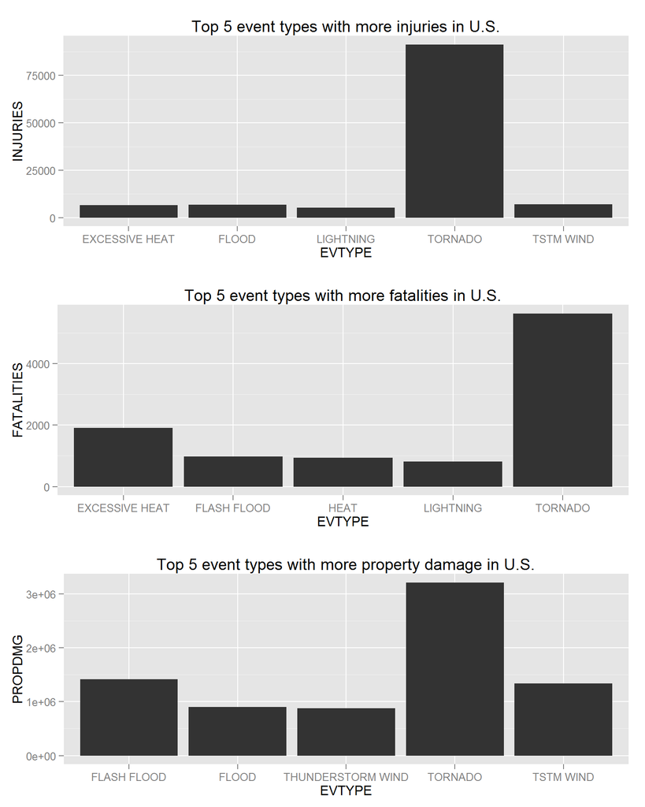

```r
library(gridExtra)
library(ggplot2)

# It's created a figure for each field
figureEventTypesByInjuries <- ggplot(data=TopFiveEventTypesByInjuries,
                                     aes(x=EVTYPE, y=INJURIES))
figureEventTypesByInjuries <- figureEventTypesByInjuries +
                              geom_bar(stat = 'identity') +
                              ggtitle("Top 5 event types with more injuries in U.S.")

figureEventTypesByFatalities <- ggplot(data=TopFiveEventTypesByFatalities,
                                     aes(x=EVTYPE, y=FATALITIES))
figureEventTypesByFatalities <- figureEventTypesByFatalities +
                                geom_bar(stat = 'identity') +
                            ggtitle("Top 5 event types with more fatalities in U.S.")

figureEventTypesByPropDMG <- ggplot(data=TopFiveEventTypesByPropDMG,
                                     aes(x=EVTYPE, y=PROPDMG))
figureEventTypesByPropDMG <- figureEventTypesByPropDMG +
                             geom_bar(stat = 'identity') +
                        ggtitle("Top 5 event types with more property damage in U.S.")

# It's shown the graphics in a panel
figuresTopFiveEventTypes <- list( figureEventTypesByInjuries,
                                  figureEventTypesByFatalities,
                                  figureEventTypesByPropDMG)

do.call(grid.arrange,figuresTopFiveEventTypes)
```

Apart of figures I attached some tables with the top 10 of event type that causes more impact in economy and population health in U.S.

Here is the top 10 event types that produce more injuries in U.S.:

```r
library(xtable)
tableTopTenInjuriesPerEventType <- xtable(head(injuriesPerTypeOfEventOrdered, 10))
names(tableTopTenInjuriesPerEventType) <- c("Event Type", "Number of Injuries")
print(tableTopTenInjuriesPerEventType,
      type="html",
      html.table.attributes = list("border='1' align='center' width='500px' "))
```

|  | Event Type | Number of Injuries |
| --- | --- | --- |
| 834 | TORNADO | 91346.00 |
| 856 | TSTM WIND | 6957.00 |
| 170 | FLOOD | 6789.00 |
| 130 | EXCESSIVE HEAT | 6525.00 |
| 464 | LIGHTNING | 5230.00 |
| 275 | HEAT | 2100.00 |
| 427 | ICE STORM | 1975.00 |
| 153 | FLASH FLOOD | 1777.00 |
| 760 | THUNDERSTORM WIND | 1488.00 |
| 244 | HAIL | 1361.00 |

Here is the top 10 event types that produce more fatalities in U.S.:

```r
library(xtable)
tableTopTenFatalitiesPerEventType <- xtable(head(fatalitiesPerTypeOfEventOrdered, 10))
names(tableTopTenFatalitiesPerEventType) <- c("Event Type", "Number of Fatalities")
print(tableTopTenFatalitiesPerEventType,
      type="html",
      html.table.attributes = list("border='1' align='center' width='500px' "))
```

|  | Event Type | Number of Fatalities |
| --- | --- | --- |
| 834 | TORNADO | 5633.00 |
| 130 | EXCESSIVE HEAT | 1903.00 |
| 153 | FLASH FLOOD | 978.00 |
| 275 | HEAT | 937.00 |
| 464 | LIGHTNING | 816.00 |
| 856 | TSTM WIND | 504.00 |
| 170 | FLOOD | 470.00 |
| 585 | RIP CURRENT | 368.00 |
| 359 | HIGH WIND | 248.00 |
| 19 | AVALANCHE | 224.00 |

And finally here is the top 10 event types that produce more property damage in U.S.:

```r
library(xtable)
tableTopTenPropDMGPerEventType <- xtable(head(propDamagePerTypeOfEventOrdered, 10))
names(tableTopTenPropDMGPerEventType) <- c("Event Type", "Property damage")
print(tableTopTenPropDMGPerEventType,
      type="html",
      html.table.attributes = list("border='1' align='center' width='500px' "))
```

|  | Event Type | Property damage |
| --- | --- | --- |
| 834 | TORNADO | 3212258.16 |
| 153 | FLASH FLOOD | 1420124.59 |
| 856 | TSTM WIND | 1335965.61 |
| 170 | FLOOD | 899938.48 |
| 760 | THUNDERSTORM WIND | 876844.17 |
| 244 | HAIL | 688693.38 |
| 464 | LIGHTNING | 603351.78 |
| 786 | THUNDERSTORM WINDS | 446293.18 |
| 359 | HIGH WIND | 324731.56 |
| 972 | WINTER STORM | 132720.59 |

Also is possible to realize that some weather events happen during some periods of time, so I think is a nice thing to see this data per year and see how the impact of weather events is changing during the time.

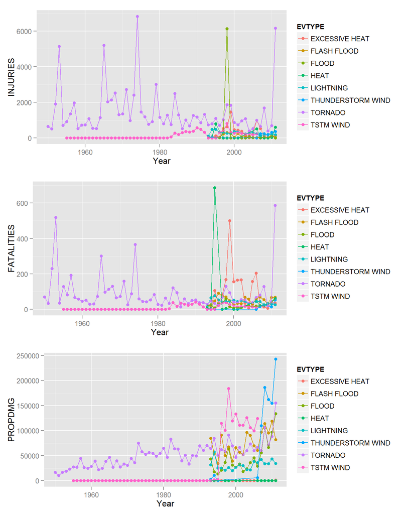

```r
injuriesPerYear <- qplot(Year,
                             INJURIES,
                             data = injuriesPerEventTypeAndYear,
                             geom = c("point", "line"),
                             col = EVTYPE)
fatalitiesPerYear <- qplot(Year,
                             FATALITIES,
                             data = fatalitiesPerTypeOfEventAndYear,
                             geom = c("point", "line"),
                             col = EVTYPE)
propDamagePerYear <- qplot(Year,
                             PROPDMG,
                             data = propDamagePerTypeOfEventAndYear,
                             geom = c("point", "line"),
                             col = EVTYPE)

# Plot the data per year
figuresPerYear <- list(injuriesPerYear,
                           fatalitiesPerYear,
                           propDamagePerYear)

do.call(grid.arrange,figuresPerYear)
```

The very first thing we can see in this graphic is that exist some lack of data about some event types in years before 1995, the second thing is that in population health (injuries and fatalities) the event type with the most impact are tornados with some spikes of injuries because floods in 1998 and spikes in fatalities because heat and excesive heat in some recent years. The economy has a bunch of event types that affects it in apparently the same level of property damage, but in recents years, thunderstorm winds has dealt the major part of property damage.

Some weather events just happen in some parts of the year, so it’s cool to see when happen more weather events during a year. This could be seen in the next plot:

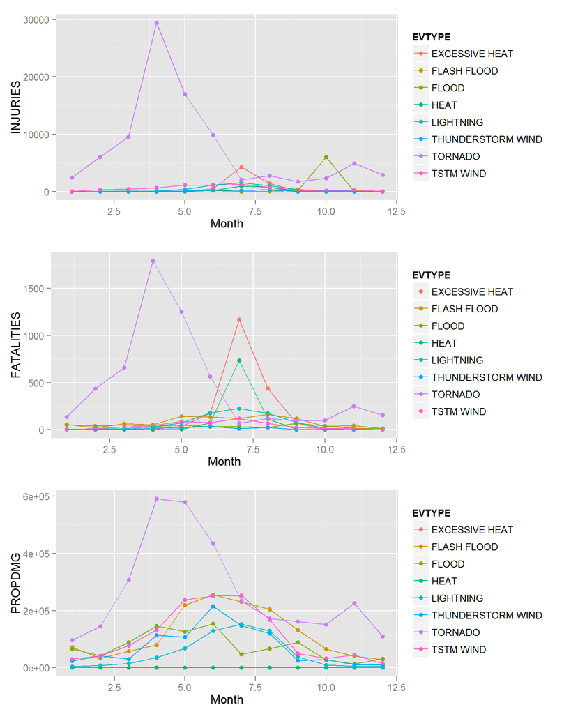

```r
injuriesPerMonth <- qplot(Month,
                             INJURIES,
                             data = injuriesPerEventTypeAndMonth,
                             geom = c("point", "line"),
                             col = EVTYPE)
fatalitiesPerMonth <- qplot(Month,
                             FATALITIES,
                             data = fatalitiesPerTypeOfEventAndMonth,
                             geom = c("point", "line"),
                             col = EVTYPE)
propDamagePerMonth <- qplot(Month,
                             PROPDMG,
                             data = propDamagePerTypeOfEventAndMonth,
                             geom = c("point", "line"),
                             col = EVTYPE)

# Plot the data per Month
figuresPerMonth <- list(injuriesPerMonth,
                           fatalitiesPerMonth,
                           propDamagePerMonth)

do.call(grid.arrange,figuresPerMonth)
```

I made this graphic because I know that U.S. has stations, so it’s pretty important to point when weather events produce more impact in population health and economy. Tornados has a big relevance in months close to April, but decrease after that with some minor spikes in November.

The others event types (excesive heat, flash floods, floods, heat, lightnings, thunderstorm winds and TSTM winds) have a raise close to June, with some exceptions like the increasing amount of injueries during October due to floods.